# DES_part3_03694565

## Programming Assignment - Part 3

### 3.2 Verification

#### Task 3.2.1: Verification of distributions

```python
import part3_simstudy
import matplotlib
matplotlib.rcParams['figure.figsize'] = (20,15)
```

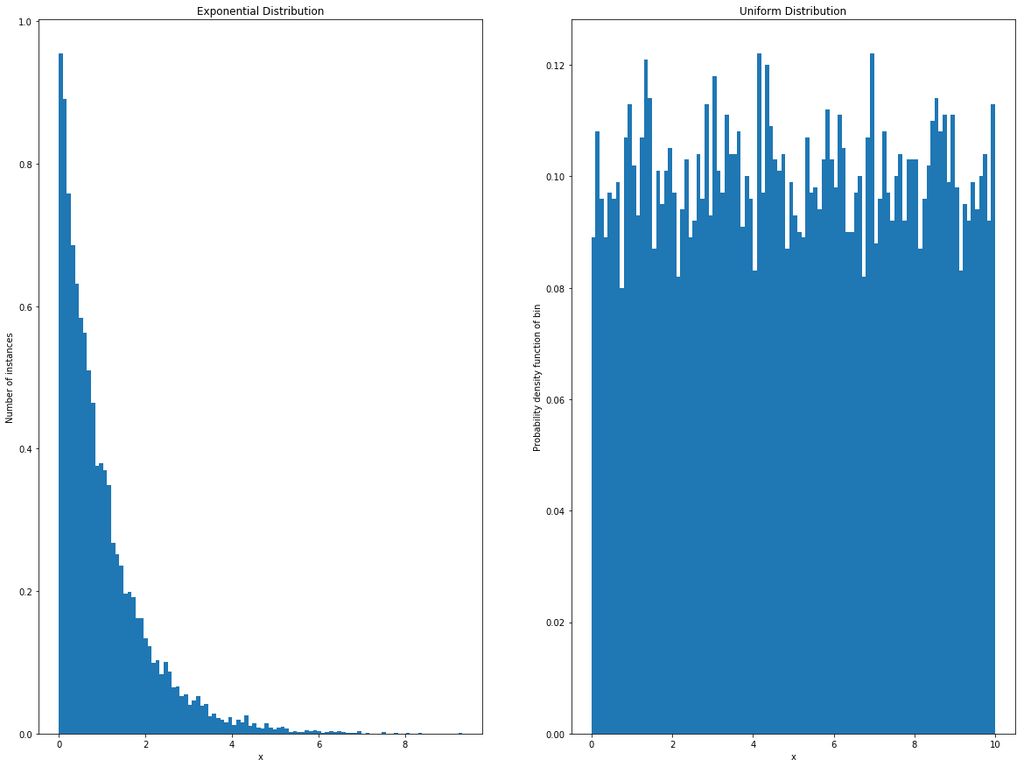

```python
part3_simstudy.task_3_2_1()
```

#### Task 3.2.2: Verification of system utilization

```python
part3_simstudy.task_3_2_2()
```

```
S = 5
system_utilization = 0.008631167822483288 RHO 0.01 Sim.Time=100s
system_utilization = 0.43155839112417094 RHO 0.5 Sim.Time=100s
system_utilization = 0.6844310119414481 RHO 0.8 Sim.Time=100s
system_utilization = 0.7338248819989631 RHO 0.9 Sim.Time=100s
system_utilization = 0.010518372948074426 RHO 0.01 Sim.Time=1000s
system_utilization = 0.525069026914957 RHO 0.5 Sim.Time=1000s
system_utilization = 0.7638777381639313 RHO 0.8 Sim.Time=1000s
system_utilization = 0.8275102040094139 RHO 0.9 Sim.Time=1000s
S = 100000
system_utilization = 0.008631167822483288 RHO 0.01 Sim.Time=100s
system_utilization = 0.43155839112417094 RHO 0.5 Sim.Time=100s
system_utilization = 0.6844310119414481 RHO 0.8 Sim.Time=100s
system_utilization = 0.7645983787343322 RHO 0.9 Sim.Time=100s
system_utilization = 0.010518372948074426 RHO 0.01 Sim.Time=1000s
system_utilization = 0.525918647403789 RHO 0.5 Sim.Time=1000s
system_utilization = 0.8414698358460628 RHO 0.8 Sim.Time=1000s
system_utilization = 0.9166986993684405 RHO 0.9 Sim.Time=1000s
S = 1
system_utilization = 0.008631167822483288 RHO 0.01 Sim.Time=100s
system_utilization = 0.3941751945925923 RHO 0.5 Sim.Time=100s
system_utilization = 0.5397738514061184 RHO 0.8 Sim.Time=100s
system_utilization = 0.5950321564999256 RHO 0.9 Sim.Time=100s
system_utilization = 0.010518372948074426 RHO 0.01 Sim.Time=1000s
system_utilization = 0.4395713803623404 RHO 0.5 Sim.Time=1000s
system_utilization = 0.5993929345350473 RHO 0.8 Sim.Time=1000s
system_utilization = 0.6368448352335958 RHO 0.9 Sim.Time=1000s
```

### Analysis and General Questions

#### Task 3.3.1: Seed for Random Number Generation

- Using the same seed in the simulation guarantees the same trace of the random variable during a simulation run which will give the same simulation results that can be repeated. Then, we can compare the different simulations with the same seed.

#### Task 3.3.2: Bins for Histograms

- If I increase the number of bins, then there will be many peaks in the simulation which makes it harder to observe distribution. If bins are small, then all the data will gather in same spot which will make it difficult to observe the behaviour of the data. There are different rules (e.g. the Freedman-Diaconis Rule, Sturges' Rule, Scott's Rule, etc.) explaining how to choose bins. However, bins should be depend on the number of samples e.g. if the samples are high, then it is better to have more bins to observe the distribution.

#### Task 3.3.2: System Utilization

- If the simulation time become infinite, then expected utilization gives more precise result and reaches its theoretical value.
- It can be observed that system utilization is the same for lower RHO values(e.g 0.1, 0.5) even if the S goes to infinite. However, for the infinite S values(e.g S=100000), system utilization reaches its optimum RHO value. Therefore, infinite S values provide theoretical result of the simulation.